# Edible wild plants recognition

## Project: Develop a model that would recognize 62 different types of wild edible plants from images

This notebook in the implementation of the Capstone Project for the Udacity Machine Learning Engineer Nanodegree. The project aims to identify wild edible plants from images. I have put together a [custom dataset for 62 edible wild plants](https://www.kaggle.com/gverzea/edible-wild-plants).

The classification problem to be solved is to identify if a given picture is that of one of the 62 edible wild plants included in the dataset. The algorithm should return either one of the 62 plants, with the related additional information, with the highest resemblance to the given picture, or decide if the given picture depicts none of the plants in the dataset.

We start by reading the images dataset.

```python
import pandas as pd
import numpy as np
from sklearn.datasets import load_files
from keras.utils import np_utils
from glob import glob
import matplotlib.pyplot as plt

import tensorflow as tf
config = tf.ConfigProto()
config.gpu_options.allow_growth = True
sess = tf.Session(config=config)

#global parameters
number_of_classes = 62

# define function to load the dataset
def load_dataset(path):
    data = load_files(path,categories=None)
    files = np.array(data['filenames'])
    labels = np.array(data['target'])
    #np.utils.to_categorical is used to convert array of labeled data(from 0 to nb_classes-1) to one-hot vector.
    one_hot_targets = np_utils.to_categorical(labels)
    return files, labels, one_hot_targets

#load the dataset
plant_files, plant_labels, plant_targets = load_dataset('./dataset')
```

```python
# load list of plant names
# item[10:-1] drops the first 10 characters and the last one - eg. "./dataset/", and the last "/", from the folder path
plant_names = [item[10:-1] for item in sorted(glob("./dataset/*/"))]
```

```
There are in total 6558 images.
There are in total 62 classes.
Plant names:  ['Alfalfa', 'Asparagus', 'Blue Vervain', 'Broadleaf Plantain', 'Bull Thistle', 'Cattail', 'Chickweed', 'Chicory', 'Cleavers', 'Coltsfoot', 'Common Sow Thistle', 'Common Yarrow', 'Coneflower', 'Creeping Charlie', 'Crimson Clover', 'Curly Dock', 'Daisy Fleabane', 'Dandellion', 'Downy Yel…
```

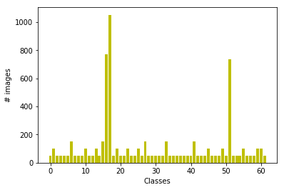

```python
# print statistics about the dataset
print("There are in total %d images." % len(plant_targets))
print("There are in total %d classes." % len(plant_names))
print("Plant names: ", plant_names)
#print("Plant target one-hot vector matrix: ", plant_targets, len(plant_targets[1]))
#print("Shape of plant_targets: ", plant_targets.shape )
#print("Plant files: ",plant_files)
#print("Shape of plant_files: ", plant_files.shape )
#print("Plant labels: ",plant_labels)
#print("Shape of plant_labels: ", plant_labels.shape )

#plant_labels.value_counts().plot(kind='barh')
unique, counts = np.unique(plant_labels, return_counts=True)
bar1 = plt.bar( unique, counts, color="y")
plt.xlabel( 'Classes' )
plt.ylabel( '# images' )
plt.show()
```

```python
#read the metadata - the information related to each class
import openpyxl
plant_details = {}
df = pd.read_excel(open('edible wild plants metadata.xls','rb'), sheet_name = 0)
names = df['Name']
descriptions = df['Description']
for i,j in enumerate(names):
    plant_details[j] = descriptions[i]
```

## Preprocess the data

The images are in .jpg format. The dimensions are not manually standardized, but this will be one step of the data preparation – to bring all the images to 100x100px. So far, I have made sure that no image exceeds 300KB, to keep the database within reasonable size limits.

As the dataset is gathered off the internet, the pictures come in different sizes and quality levels. At first I would need to pre-process the data. I would try the following actions:

The function crop centers the image and crops it around the center. The function resize_and_crop does maintain the full image, but at a reduced scale. The function pathlist2imagelist returns a list of images, from a list of file paths, while also resizing and cropping them and normalizing the image input.

```python
import cv2
from matplotlib import pyplot as plt
import imgaug
from keras.preprocessing.image import img_to_array
from keras.applications.vgg16 import preprocess_input
import sys

#make sure there are no special characters in the path (eg. "'") - or the cv2.imread will return None
def crop(path):
    #open image
    img = cv2.imread(path)
    #get center of image
    x = int(img.shape[0]/2)
    y = int(img.shape[1]/2)
    #crop 50px to the left/right and top/down
    img = img[x-50:x+50,y-50:y+50,:]
    height, width, channels = img.shape
    if height <100 or width <100 or channels < 3:
        print("-----------------------------")
        print("------ Image too small ------", path, "shape: ", height, width, channels)
        sys.exit()
    return img

def resize_and_crop(path):
    desired_size = 100
    im = cv2.imread(path)
    old_size = im.shape[:2] # old_size is in (height, width) format
    ratio = float(desired_size)/max(old_size)
    new_size = tuple([int(x*ratio) for x in old_size])

    # new_size should be in (width, height) format
    im = cv2.resize(im, (new_size[1], new_size[0]))
    delta_w = desired_size - new_size[1]
    delta_h = desired_size - new_size[0]
    top, bottom = delta_h//2, delta_h-(delta_h//2)
    left, right = delta_w//2, delta_w-(delta_w//2)
    #padding
    color = [0, 0, 0]
    new_im = cv2.copyMakeBorder(im, top, bottom, left, right, cv2.BORDER_CONSTANT, value=color)
    return new_im

def normalize_image_inputs(image):
    norm_image = cv2.normalize(image, None, alpha=0, beta=1, norm_type=cv2.NORM_MINMAX, dtype=cv2.CV_32F)
    return norm_image

# get a list of images from a list of paths
def pathlist2imagelist(pathlist):
    imagelist = []
    for path in pathlist:
        #print("path =", path)
        #img = crop(path)
        img = resize_and_crop(path)
        img_norm = normalize_image_inputs(img)

        #preprocess image list to fit keras expected input format -  4D array (4D tensor) [nb_samples,rows,columns,channels]
        # convert the image pixels to a numpy array
        img_norm = img_to_array(img_norm)
        # prepare the image for the VGG model
        img_exp = np.expand_dims(img_norm, axis=0)

        imagelist.append(img_exp)
        #if img_norm[0].shape is not 100 or img_norm[1].shape is not 100 or img_norm[2].shape is not 3:
            #print("image shape: ",img_norm.shape, path)
    #print("IMagelist shape", imagelist[0].shape, imagelist[1].shape,imagelist[2].shape)
    imglist = np.vstack(imagelist)
    return imglist
```

Testing the image processing functions ...

```
plant files 0 ./dataset\Dandellion\33877696673_2d1de2d252_n.jpg
```

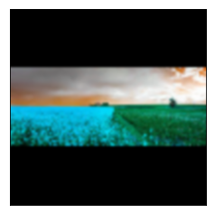

```
(100, 100, 3)
```

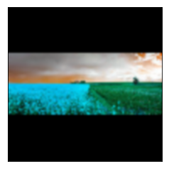

```
(100, 100, 3)
```

```python
#img = crop(plant_files[0])
img = resize_and_crop("./dataset/Dandellion/33878218914_452600b869_n.jpg")
print("plant files 0",plant_files[0])
img_norm = normalize_image_inputs(img)

plt.imshow(img, cmap = 'gray', interpolation = 'bicubic')
plt.xticks([]), plt.yticks([])  # to hide tick values on X and Y axis
plt.show()
print(img.shape)

plt.imshow(img_norm, cmap = 'gray', interpolation = 'bicubic')
plt.xticks([]), plt.yticks([])  # to hide tick values on X and Y axis
plt.show()
print(img_norm.shape)
```

## Build the transfer learning model

I will build my model using transfer learning. I have chosen the VGG16 model, and I first have to import the weights of the [VGG-16 model](https://keras.io/applications/#vgg16), trained on ImageNet. ImageNet is a project which aims to provide a large image database for research purposes. It contains more than 14 million images which belong to more than 20,000 classes ( or synsets ) I am removing the output layer, and will replace it with a series of custom layers: two Dense layers, with dropout, and a softmax layer at the end, with the 62 classes. I am adding the two Dense layers with Dropout because I have noticed that the model tends to overfit quite a lot. I am also freezing the first 10 layers of the VGG16 model, in order to save computing power.Freezing all of them resulted in very low accuracy, and freezing only 6 layers resulted also in a slightly lower accuracy.

```python
from keras.applications.vgg16 import VGG16
from keras.preprocessing import image
from keras.layers import Dropout, Flatten, Dense, GlobalAveragePooling2D, Conv2D, MaxPooling2D
from keras.models import Sequential, Model
from keras import optimizers
from keras.callbacks import ModelCheckpoint

VGG16_model = VGG16(weights='imagenet', include_top=False, input_tensor=None, input_shape=(100,100,3), pooling=None, classes=62)

# Freeze all the 19 layers, which I don't want to retrain
#for layer in VGG16_model.layers[:18]:
#for layer in VGG16_model.layers[:14]:
for layer in VGG16_model.layers[:10]:
#for layer in VGG16_model.layers[:6]:
    layer.trainable = False

#Adding custom Layers
x = VGG16_model.output
x = Flatten()(x)
x = Dense(1024, activation="relu")(x)
x = Dropout(0.8)(x)
x = Dense(1024, activation="relu")(x)
x = Dropout(0.8)(x)
#output layer with 62 classes as possible predictions
predictions = Dense(62, activation="softmax")(x)
```

```python
print(VGG16_model.summary())
```

```
_________________________________________________________________
Layer (type)                 Output Shape              Param #
=================================================================
input_1 (InputLayer)         (None, 100, 100, 3)       0
_________________________________________________________________
block1_conv1 (Conv2D)        (None, 100, 100, 64)      1792
_________________________________________________________________
block1_conv2 (Conv2D)        (None, 100, 100, 64)      36928
_________________________________________________________________
block1_pool (MaxPooling2D)   (None, 50, 50, 64)        0
_________________________________________________________________
block2_conv1 (Conv2D)        (None, 50, 50, 128)       73856
_________________________________________________________________
block2_conv2 (Conv2D)        (None, 50, 50, 128)       147584
_________________________________________________________________
block2_pool (MaxPooling2D)   (None, 25, 25, 128)       0
_________________________________________________________________
block3_conv1 (Conv2D)        (None, 25, 25, 256)       295168
_________________________________________________________________
block3_conv2 (Conv2D)        (None, 25, 25, 256)       590080
_________________________________________________________________
block3_conv3 (Conv2D)        (None, 25, 25, 256)       590080
_________________________________________________________________
block3_pool (MaxPooling2D)   (None, 12, 12, 256)       0
_________________________________________________________________
block4_conv1 (Conv2D)        (None, 12, 12, 512)       1180160
_________________________________________________________________
block4_conv2 (Conv2D)        (None, 12, 12, 512)       2359808
_________________________________________________________________
block4_conv3 (Conv2D)        (None, 12, 12, 512)       2359808
_________________________________________________________________
block4_pool (MaxPooling2D)   (None, 6, 6, 512)         0
_________________________________________________________________
block5_conv1 (Conv2D)        (None, 6, 6, 512)         2359808
_________________________________________________________________
block5_conv2 (Conv2D)        (None, 6, 6, 512)         2359808
_________________________________________________________________
block5_conv3 (Conv2D)        (None, 6, 6, 512)         2359808
_________________________________________________________________
block5_pool (MaxPooling2D)   (None, 3, 3, 512)         0
=================================================================
Total params: 14,714,688
Trainable params: 12,979,200
Non-trainable params: 1,735,488
_________________________________________________________________
None
```

## Split the training, dev and test datasets, and fit the model

To preserve the class balances across the train/test datasets, I am using the [Stratified K-Folds cross-validator](http://scikit-learn.org/stable/modules/generated/sklearn.model_selection.StratifiedKFold.html#sklearn.model_selection.StratifiedKFold). This cross-validation object is a variation of KFold that returns stratified folds. The folds are made by preserving the percentage of samples for each class.

Because I am training the model on my laptop's GPU, I have to be extra sensible to performance and training time. For this, I did have to apply some restrictions that are potentially limiting the final model accuracy:

Also, because of the long training time, I am saving the weights after each epoch, if they improve.

I do the fitting using Keras's ImageDataGenerator, applying some data augmentation. I chose to do this, and it has improved my model's accuracy, as the dataset size is still quite limited.

```python
from sklearn.model_selection import StratifiedKFold
from keras.preprocessing.image import ImageDataGenerator
from keras.applications.vgg16 import decode_predictions

skf = StratifiedKFold(n_splits=10, random_state=12)
avg_loss = []
avg_acc = []
# Loop through the indices the split() method returns
for index, (train_index, test_index) in enumerate(skf.split(plant_files, plant_labels)):
    print("Training on fold " + str(index+1) + "/10.............................................")
    # Generate batches from indices
    xtrain, xtest = plant_files[train_index], plant_files[test_index]
    # use one-hot vectors as labels
    ytrain, ytest = plant_targets[train_index], plant_targets[test_index]

    # Clear the model, and create it
    model = None
    model = Model(input = VGG16_model.input, output = predictions)

    # load best weights so far
    model.load_weights("final_model_weights.hdf5")

    # if your targets are one-hot encoded, use categorical_crossentropy, but if your targets are integers, use sparse_categorical_crossentropy
    model.compile(loss = "categorical_crossentropy", optimizer = optimizers.SGD(lr=0.0001, momentum=0.7), metrics=['accuracy'])
    #model.compile(loss = "categorical_crossentropy", optimizer = optimizers.SGD(lr=0.0001, momentum=0.9), metrics={'output_a': 'accuracy', 'output_b': 'precision'})
    #model.compile(loss = "sparse_categorical_crossentropy", optimizer = optimizers.SGD(lr=0.0001, momentum=0.9), metrics=["accuracy"])

    # create checkpoint after each epoch in the fitting process
    filepath="final_model_weights.hdf5"
    checkpoint = ModelCheckpoint(filepath, monitor='val_acc', verbose=1, save_best_only=True, save_weights_only=False, mode='max', period=1)
    callbacks_list = [checkpoint]

    # open all the images from the xtrain and ytrain paths, crop and normalize them
    xtrain_imagelist = pathlist2imagelist(xtrain)
    xtest_imagelist = pathlist2imagelist(xtest)

    # fit the model - only a few epochs, to save time
    #model.fit(xtrain_imagelist, ytrain, validation_data=(xtest_imagelist, ytest), epochs=1, callbacks=callbacks_list, verbose=1)

    #fit the model with image augmentation
    datagen = ImageDataGenerator(rotation_range=20, width_shift_range=0.2, height_shift_range=0.2, horizontal_flip=True)
    #fit it on the data - this will calculate any statistics required to actually perform the transforms on the image data.
    datagen.fit(xtrain_imagelist)
    # steps_per_epoch * batch_size images will be loaded per each epoch
    model.fit_generator(datagen.flow(xtrain_imagelist, ytrain, batch_size=32), steps_per_epoch=1200, validation_data=(xtest_imagelist, ytest), epochs=1, callbacks=callbacks_list, verbose=1)

    #evaluate and store the accuracy
    loss, accuracy = model.evaluate(xtest_imagelist, ytest, verbose=1)
    avg_loss.append(loss)
    avg_acc.append(accuracy)
```

```
Training on fold 1/10.............................................
```

```
Epoch 00001: val_acc improved from -inf to 1.00000, saving model to final_model_weights.hdf5
Training on fold 2/10.............................................

Epoch 00001: val_acc improved from -inf to 0.99696, saving model to final_model_weights.hdf5
Training on fold 3/10.............................................

Epoch 00001: val_acc improved from -inf to 0.99696, saving model to final_model_weights.hdf5
Training on fold 4/10.............................................

Epoch 00001: val_acc improved from -inf to 0.99848, saving model to final_model_weights.hdf5
Training on fold 5/10.............................................

Epoch 00001: val_acc improved from -inf to 0.99848, saving model to final_model_weights.hdf5
Training on fold 6/10.............................................

Epoch 00001: val_acc improved from -inf to 0.99847, saving model to final_model_weights.hdf5
Training on fold 7/10.............................................

Epoch 00001: val_acc improved from -inf to 0.99847, saving model to final_model_weights.hdf5
Training on fold 8/10.............................................

Epoch 00001: val_acc improved from -inf to 0.99847, saving model to final_model_weights.hdf5
Training on fold 9/10.............................................

Epoch 00001: val_acc improved from -inf to 1.00000, saving model to final_model_weights.hdf5
Training on fold 10/10.............................................

Epoch 00001: val_acc improved from -inf to 0.99237, saving model to final_model_weights.hdf5
```

```python
#cross validation score
print("Average accuracy of model on the dev set = ", np.mean(avg_acc))
```

```
Average accuracy of model on the dev set =  0.9978649198993297
```

## Creating the Benchmark model

For the benchmark model I have chosen a simple vanilla CNN.

[figure not shown]

The model contains 2 Conv layers, separated by a Pooling layer each, to reduce the number of parameters, and to make the feature detection invariant to scale and orientation changes. To connect the output of the pooling layer to the last 2 fully connected layers, we need to flatten this output into a single tensor. The last fully connected layer contains the softmax to the 62 classes.

```python
vanilla_model = Sequential()
vanilla_model.add(Conv2D(32, kernel_size=(5, 5), strides=(1, 1),
                 activation='relu',
                 input_shape=(100,100,3)))
vanilla_model.add(MaxPooling2D(pool_size=(2, 2), strides=(2, 2)))
vanilla_model.add(Conv2D(64, (5, 5), activation='relu'))
vanilla_model.add(MaxPooling2D(pool_size=(2, 2)))
vanilla_model.add(Flatten())
vanilla_model.add(Dense(1000, activation='relu'))
vanilla_model.add(Dense(62, activation='softmax'))

print(vanilla_model.summary())
```

```
_________________________________________________________________
Layer (type)                 Output Shape              Param #
=================================================================
conv2d_1 (Conv2D)            (None, 96, 96, 32)        2432
_________________________________________________________________
max_pooling2d_1 (MaxPooling2 (None, 48, 48, 32)        0
_________________________________________________________________
conv2d_2 (Conv2D)            (None, 44, 44, 64)        51264
_________________________________________________________________
max_pooling2d_2 (MaxPooling2 (None, 22, 22, 64)        0
_________________________________________________________________
flatten_2 (Flatten)          (None, 30976)             0
_________________________________________________________________
dense_4 (Dense)              (None, 1000)              30977000
_________________________________________________________________
dense_5 (Dense)              (None, 62)                62062
=================================================================
Total params: 31,092,758
Trainable params: 31,092,758
Non-trainable params: 0
_________________________________________________________________
None
```

## Compile and fit the Benchmark model

```python
# load best weights so far
vanilla_model.load_weights("vanilla_model_weights.hdf5")

vanilla_model.compile(loss="categorical_crossentropy", optimizer = optimizers.SGD(lr=0.0001, momentum=0.9), metrics=['accuracy'])

# create checkpoint after each epoch in the fitting process
vanilla_filepath="vanilla_model_weights.hdf5"
checkpoint = ModelCheckpoint(vanilla_filepath, monitor='val_acc', verbose=1, save_best_only=True, save_weights_only=False, mode='max', period=1)
vanilla_callbacks_list = [checkpoint]

vanilla_model.fit(xtrain_imagelist, ytrain, epochs=50, verbose=1, validation_data=(xtest_imagelist, ytest), callbacks=vanilla_callbacks_list)

score = vanilla_model.evaluate(xtest_imagelist, ytest, verbose=1)
print("Vanilla Model evaluation: ", score[0], score[1])
```

```
Train on 5903 samples, validate on 655 samples

Epoch 00001: val_acc improved from -inf to 0.74351, saving model to vanilla_model_weights.hdf5

Epoch 00002: val_acc did not improve from 0.74351

Epoch 00003: val_acc did not improve from 0.74351

Epoch 00004: val_acc did not improve from 0.74351

Epoch 00005: val_acc did not improve from 0.74351

Epoch 00006: val_acc did not improve from 0.74351

Epoch 00007: val_acc did not improve from 0.74351

Epoch 00008: val_acc did not improve from 0.74351

Epoch 00009: val_acc did not improve from 0.74351

Epoch 00010: val_acc did not improve from 0.74351

Epoch 00011: val_acc did not improve from 0.74351

Epoch 00012: val_acc did not improve from 0.74351

Epoch 00013: val_acc did not improve from 0.74351

Epoch 00014: val_acc did not improve from 0.74351

Epoch 00015: val_acc did not improve from 0.74351

Epoch 00016: val_acc did not improve from 0.74351

Epoch 00017: val_acc did not improve from 0.74351

Epoch 00018: val_acc did not improve from 0.74351

Epoch 00019: val_acc did not improve from 0.74351

```

[output cut: 47 more lines]

```

Epoch 00044: val_acc did not improve from 0.74351

Epoch 00045: val_acc did not improve from 0.74351

Epoch 00046: val_acc did not improve from 0.74351

Epoch 00047: val_acc did not improve from 0.74351

Epoch 00048: val_acc did not improve from 0.74351

Epoch 00049: val_acc did not improve from 0.74351

Epoch 00050: val_acc did not improve from 0.74351
Vanilla Model evaluation:  1.5131217962002936 0.6992366414943724
```

## Test the models on new data

After having tested the models in the dev set, it is time to test the model on new data - that the model has never seen. I have built a separate folder for the test data, with 5 images per class - so 310 test images in total.

```python
#load the test dataset
plant_files_test, plant_labels_test, plant_targets_test = load_dataset('./dataset-test')
#convert list of paths to list of images
plant_files_test_imagelist = pathlist2imagelist(plant_files_test)
#evaluate the accuracy on the test set
print("Testing the VGG16 model ...")
model.load_weights("final_model_weights.hdf5")
pred_test_labels = model.predict(plant_files_test_imagelist)
loss, accuracy = model.evaluate(plant_files_test_imagelist, plant_targets_test, verbose=1)
print("Test dataset loss = ", loss,"; accuracy = ", accuracy)

print("Testing the vanilla model ...")
vanilla_model.load_weights("vanilla_model_weights.hdf5")
vanilla_loss, vanilla_accuracy = vanilla_model.evaluate(plant_files_test_imagelist, plant_targets_test, verbose=1)
print("Test dataset loss = ", vanilla_loss,"; accuracy = ", vanilla_accuracy)
```

```
Testing the VGG16 model ...
Test dataset loss =  3.674458300682806 ; accuracy =  0.606451613864591
Testing the vanilla model ...
Test dataset loss =  5.194462099382954 ; accuracy =  0.1419354840632408
```

## Understanding and exploring the results

TO be able to understand where the model is doign well,and where it needs improvement, I am showing a confusion matrix.

As due to the large number of classes it is not very readable, I am also showing the number of correct predictions, per class, out of the 5 maximmum correct predictions. I am using these to target the classes where the algorithm performs the worst, and invest time to find and provide more training images.

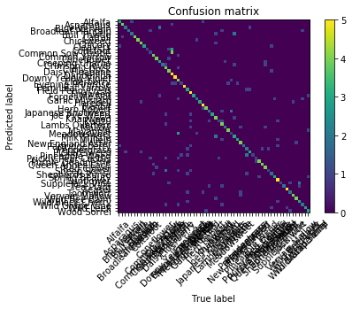

```
Check how many right predictins we have, out of 5 examples per each class:
Correct predictions for class  Alfalfa  :  3
Correct predictions for class  Asparagus  :  4
Correct predictions for class  Blue Vervain  :  2
Correct predictions for class  Broadleaf Plantain  :  2
Correct predictions for class  Bull Thistle  :  2
Correct predictions for class  Cattail  :  4
Correct predictions for class  Chickweed  :  4
Correct predictions for class  Chicory  :  4
Correct predictions for class  Cleavers  :  3
Correct predictions for class  Coltsfoot  :  1
Correct predictions for class  Common Sow Thistle  :  1
Correct predictions for class  Common Yarrow  :  4
Correct predictions for class  Coneflower  :  4
Correct predictions for class  Creeping Charlie  :  3
Correct predictions for class  Crimson Clover  :  2
Correct predictions for class  Curly Dock  :  4
Correct predictions for class  Daisy Fleabane  :  4
Correct predictions for class  Dandellion  :  5
Correct predictions for class  Downy Yellow Violet  :  5
Correct predictions for class  Elderberry  :  4
Correct predictions for class  Evening Primrose  :  1
Correct predictions for class  Fern Leaf Yarrow  :  5
Correct predictions for class  Field Pennycress  :  3
Correct predictions for class  Fireweed  :  5
Correct predictions for class  Forget Me Not  :  3
Correct predictions for class  Garlic Mustard  :  2
Correct predictions for class  Harebell  :  3
Correct predictions for class  Henbit  :  5
Correct predictions for class  Herb Robert  :  4
Correct predictions for class  Japanese Knotweed  :  2
Correct predictions for class  Joe Pye Weed  :  3
Correct predictions for class  Knapweed  :  4
Correct predictions for class  Kudzu  :  1
Correct predictions for class  Lambs Quarters  :  4
Correct predictions for class  Mallow  :  2
Correct predictions for class  Mayapple  :  4
Correct predictions for class  Meadowsweet  :  1
Correct predictions for class  Milk Thistle  :  3
Correct predictions for class  Mullein  :  3
```

[output cut: 8 more lines]

```
Correct predictions for class  Red Clover  :  4
Correct predictions for class  Sheep Sorrel  :  1
Correct predictions for class  Shepherds Purse  :  2
Correct predictions for class  Spring Beauty  :  3
Correct predictions for class  Sunflower  :  5
Correct predictions for class  Supplejack Vine  :  1
Correct predictions for class  Tea Plant  :  2
Correct predictions for class  Teasel  :  5
Correct predictions for class  Toothwort  :  2
Correct predictions for class  Vervain Mallow  :  4
Correct predictions for class  Wild Bee Balm  :  4
Correct predictions for class  Wild Black Cherry  :  3
Correct predictions for class  Wild Grape Vine  :  2
Correct predictions for class  Wild Leek  :  3
Correct predictions for class  Wood Sorrel  :  3
```

```python
#confusion matrix for text data
from sklearn.metrics import confusion_matrix
import matplotlib.pyplot as plt
import itertools
#Your input to confusion_matrix must be an array of int not one hot encodings
cm = confusion_matrix(plant_targets_test.argmax(axis=-1), pred_test_labels.argmax(axis=-1))
#print(cm)
plt.imshow(cm, interpolation='nearest')
plt.title('Confusion matrix')
plt.colorbar()
tick_marks = np.arange(len(plant_names))
plt.xticks(tick_marks, plant_names, rotation=45)
plt.yticks(tick_marks, plant_names)
fmt = '.2f'
#for i, j in itertools.product(range(cm.shape[0]), range(cm.shape[1])): plt.text(j, i, format(cm[i, j], fmt), horizontalalignment="center", color="white" if cm[i, j] > thresh else "black")

plt.xlabel('True label')
plt.ylabel('Predicted label')
#plt.tight_layout()
plt.show()

print("Check how many right predictins we have, out of 5 examples per each class:")
for i in range (0,cm.shape[0]):
    print("Correct predictions for class ", plant_names[i], " : ", cm[i][i])
```

## Provide an interface for user images

Because a potential usage of this model would be usage on a mobile app, it is important to be able to test with user images. These should be added to the folder "dataset-user_images",and the model will predict their classes.

```
Predicting image  ./dataset-user_images\Alfalfa.jpg
```

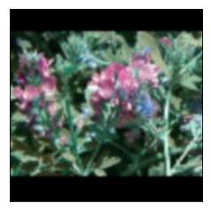

```
Predicted class for above image:  Wild Leek [60] , with confidence level  1.0
Details on this plant:
A North American species of wild onion that grow deep in the woods. It is bulb-forming with broad, smooth, light green leaves.
Be sure to look out for the deep purple or burgundy tints on the lower stem. You can also identify them by their smell, which is similar to that of an onion.
The leaves and bulbs are edible but it is best if you consume them in small quantities.
---------------------------------------------------
Predicting image  ./dataset-user_images\Alfalfa2.jpg
```

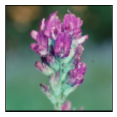

```
Predicted class for above image:  Red Clover [47] , with confidence level  0.86798286
Details on this plant:
Along with its many medicinal uses, Red Clovers are considered to be the tastiest of all clovers and will surely make a good find. It has a reddish flower head made up of different tubular-shaped flowers. The leaves are edible but the flower is what I would look forward to consuming!
---------------------------------------------------
Predicting image  ./dataset-user_images\Asparagus.jpg
```

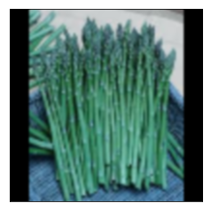

```
Predicted class for above image:  Asparagus [1] , with confidence level  1.0
Details on this plant:
Asparagus, easily identified by its fleshy green spears which are luscious and delicate, can be eaten raw as opposed to boiled. It is a good source of vitamin C and potassium.

Be mindful of wild Asparagus which has a thinner stalk than those usually found in grocery-stores.

Harvest length of these plants are usually 6-8 inches.
---------------------------------------------------
Predicting image  ./dataset-user_images\Beavis_and_butt_head.jpg
```

[figure not shown]

```
Predicted class for above image:  Elderberry [19] , with confidence level  1.0
Details on this plant:
Found mostly in temperate to subtropical regions of the world, many species are widely cultivated to be used as ornaments.
However, the Elderberry’s flower, as well as its fruit, is edible, although, the raw fruit does not yield a favourable taste.
The fruit, when ripe, is a purplish-black colour. All other parts of this bush are toxic.Found mostly in temperate to subtropical regions of the world, many species are widely cultivated to be used as ornaments.
However, the Elderberry’s flower, as well as its fruit, is edible, although, the raw fruit does not yield a favourable taste.
The fruit, when ripe, is a purplish-black colour. All other parts of this bush are toxic.Found mostly in temperate to subtropical regions of the world, many species are widely cultivated to be used as ornaments.
However, the Elderberry’s flower, as well as its fruit, is edible, although, the raw fruit does not yield a favourable taste.
The fruit, when ripe, is a purplish-black colour. All other parts of this bush are toxic.
---------------------------------------------------
Predicting image  ./dataset-user_images\Blue_Vervain.jpg
```

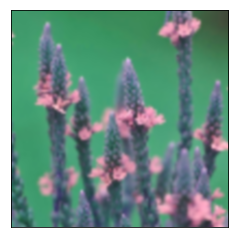

```
Predicted class for above image:  Daisy Fleabane [16] , with confidence level  1.0
Details on this plant:
Another plant with a hairy nature; the Daisy Fleabane is an attractive plant with composite flowers. It has hairy leaves and stems and is best grown in areas exposed to full sun.
Only the leaves of this plant are edible, although, you might frown while eating them as its hairy nature might result in an unpleasant taste.Another plant with a hairy nature; the Daisy Fleabane is an attractive plant with composite flowers. It has hairy leaves and stems and is best grown in areas …
Only the leaves of this plant are edible, although, you might frown while eating them as its hairy nature might result in an unpleasant taste.Another plant with a hairy nature; the Daisy Fleabane is an attractive plant with composite flowers. It has hairy leaves and stems and is best grown in areas …
Only the leaves of this plant are edible, although, you might frown while eating them as its hairy nature might result in an unpleasant taste.
---------------------------------------------------
Predicting image  ./dataset-user_images\Broadleaf_plantain.jpg
```

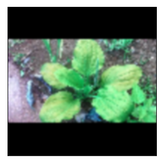

```
Predicted class for above image:  Broadleaf Plantain [3] , with confidence level  1.0
Details on this plant:
A species of the plantain family, Broadleaf Plantain is rich in vitamins A, C and K. The leaves are green and oval-shaped with thick-stemmed leaves that meet at a base.
The entire plant is edible but it recommended that the leaves be eaten raw while they are young and tender.
---------------------------------------------------
Predicting image  ./dataset-user_images\Chicory.jpg
```

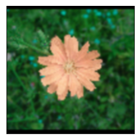

```
Predicted class for above image:  Vervain Mallow [56] , with confidence level  1.0
Details on this plant:
This plant prefers sunny or partially shaded areas and mostly grows in thickets and in waste areas. They can grow from 50cm to over 1 metre tall. Their flowerhave five white to pink petals with five green sepals. The flowers, leaves, and seed are edible, although, it is recommended that only the lea…
---------------------------------------------------
Predicting image  ./dataset-user_images\Dandellion.jpg
```

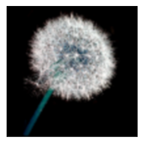

```
Predicted class for above image:  Dandellion [17] , with confidence level  1.0
Details on this plant:
You’re probably thinking “There’s no way I can eat this!”. However, the Taraxacum, or more commonly referred to as “Dandelion”, is, in fact, entirely edible. This means that its flowers, leaves, and even roots,are safe for consumption.
The leaves of a Dandelion are generally 5-25cm long or longer and their flower heads are yellow to orange coloured which are open during the daytime, but closed at night.You’re probably thinking “There’s no way I can eat this!”. However, the Taraxacum, or more commonly referred to as “Dandelion”, is…
The leaves of a Dandelion are generally 5-25cm long or longer and their flower heads are yellow to orange coloured which are open during the daytime, but closed at night.You’re probably thinking “There’s no way I can eat this!”. However, the Taraxacum, or more commonly referred to as “Dandelion”, is…
The leaves of a Dandelion are generally 5-25cm long or longer and their flower heads are yellow to orange coloured which are open during the daytime, but closed at night.
---------------------------------------------------
Predicting image  ./dataset-user_images\lambo.jpg
```

[figure not shown]

```
Predicted class for above image:  Daisy Fleabane [16] , with confidence level  1.0
Details on this plant:
Another plant with a hairy nature; the Daisy Fleabane is an attractive plant with composite flowers. It has hairy leaves and stems and is best grown in areas exposed to full sun.
Only the leaves of this plant are edible, although, you might frown while eating them as its hairy nature might result in an unpleasant taste.Another plant with a hairy nature; the Daisy Fleabane is an attractive plant with composite flowers. It has hairy leaves and stems and is best grown in areas …
Only the leaves of this plant are edible, although, you might frown while eating them as its hairy nature might result in an unpleasant taste.Another plant with a hairy nature; the Daisy Fleabane is an attractive plant with composite flowers. It has hairy leaves and stems and is best grown in areas …
Only the leaves of this plant are edible, although, you might frown while eating them as its hairy nature might result in an unpleasant taste.
---------------------------------------------------
Predicting image  ./dataset-user_images\Sunflower.jpg
```

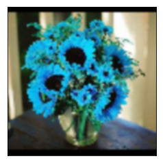

```
Predicted class for above image:  Elderberry [19] , with confidence level  1.0
Details on this plant:
Found mostly in temperate to subtropical regions of the world, many species are widely cultivated to be used as ornaments.
However, the Elderberry’s flower, as well as its fruit, is edible, although, the raw fruit does not yield a favourable taste.
The fruit, when ripe, is a purplish-black colour. All other parts of this bush are toxic.Found mostly in temperate to subtropical regions of the world, many species are widely cultivated to be used as ornaments.
However, the Elderberry’s flower, as well as its fruit, is edible, although, the raw fruit does not yield a favourable taste.
The fruit, when ripe, is a purplish-black colour. All other parts of this bush are toxic.Found mostly in temperate to subtropical regions of the world, many species are widely cultivated to be used as ornaments.
However, the Elderberry’s flower, as well as its fruit, is edible, although, the raw fruit does not yield a favourable taste.
The fruit, when ripe, is a purplish-black colour. All other parts of this bush are toxic.
---------------------------------------------------
```

```python
#predict the class for an user image
from keras.applications.vgg16 import decode_predictions

path = './dataset-user_images'
imgs = glob(path + "/*.jpg")

for i in imgs:
    print("Predicting image ", i)
    img = resize_and_crop(i)
    plt.imshow(img, cmap = 'gray', interpolation = 'bicubic')
    plt.xticks([]), plt.yticks([])  # to hide tick values on X and Y axis
    plt.show()
    img = img_to_array(img)
    img = np.expand_dims(img, axis=0)
    img = preprocess_input(img)
    predicted_classes = model.predict(img)
    predicted_class = predicted_classes.argmax(axis=-1)
    confidence = predicted_classes.max()
    if confidence >= 0.8 :
        print("Predicted class for above image: ", plant_names[int(predicted_class)], predicted_class, ", with confidence level ", confidence)
        print("Details on this plant: ")
        print(plant_details[plant_names[int(predicted_class)]])
    else:
        print("This image does not represent a plant from the 62 wild edible plants dataset.")
    print("---------------------------------------------------")
```